# Titanic Analysis

## Introduction

##### The RMS Titanic was a British passenger liner that gained global fame due to its tragic sinking on its maiden voyage in April 1912. At the time, the Titanic was one of the largest and most luxurious ships ever built, often referred to as the "unsinkable" ship. The disaster occurred during the night of April 14-15, 1912, when the ship struck an iceberg in the North Atlantic Ocean.

##### The Titanic was part of the White Star Line's trio of Olympic-class ocean liners, which also included the RMS Olympic and HMHS Britannic. It was constructed in the Harland and Wolff shipyards in Belfast, Northern Ireland. The ship was heralded for its opulence and cutting-edge technology.

##### The Titanic set sail on its maiden voyage from Southampton, England, on April 10, 1912, with stops in Cherbourg, France, and Queenstown (now known as Cobh), Ireland, before heading across the Atlantic to its final destination, New York City. On the night of April 14, 1912, the Titanic struck an iceberg about 375 miles south of Newfoundland. The iceberg caused significant damage to the ship's hull, leading to its eventual sinking. The ship carried a limited number of lifeboats, and the evacuation process was chaotic, resulting in the loss of over 1500 lives.

##### The Titanic carried a diverse group of passengers, including wealthy industrialists, immigrants seeking a new life in America, and crew members. The class distinction among passengers became notable during the evacuation, as first-class passengers were given priority access to lifeboats.

##### The sinking of the Titanic captured global attention and shocked the world. The media extensively covered the disaster, and the public was deeply affected by the loss of life. The tragedy led to changes in maritime safety regulations and practices.

##### The sinking of the Titanic has become a symbol of human hubris and the unpredictable forces of nature. Numerous books, documentaries, and films have been produced about the Titanic, contributing to its enduring place in popular culture.

## Objective:

##### The primary objective of this project is to conduct a comprehensive analysis of the Titanic dataset, shedding light on patterns, correlations, and insights that can deepen our understanding of the events surrounding the disaster. I seek to answer a multitude of questions, exploring the impact of socio-economic factors, family relationships, age, gender, and other variables on the likelihood of survival. Through statistical analysis and visualization techniques, I aim to discern underlying trends, draw meaningful conclusions, and contribute to the broader narrative of the Titanic tragedy.

### Import Libraries

```python
import numpy as np
import pandas as pd
import matplotlib.pyplot as plt
import seaborn as sns
```

### Import Dataset

```python
df=pd.read_csv(r"C:\Users\Inioluwa Akintunlaji\Downloads\titanic.csv")
df
```

|  | PassengerId | Survived | Pclass | Name | Sex | Age | SibSp | Parch | Ticket | Fare | Cabin | Embarked |
| --- | --- | --- | --- | --- | --- | --- | --- | --- | --- | --- | --- | --- |
| 0 | 1 | 0 | 3 | Braund, Mr. Owen Harris | male | 22.0 | 1 | 0 | A/5 21171 | 7.2500 | NaN | S |
| 1 | 2 | 1 | 1 | Cumings, Mrs. John Bradley (Florence Briggs Th... | female | 38.0 | 1 | 0 | PC 17599 | 71.2833 | C85 | C |
| 2 | 3 | 1 | 3 | Heikkinen, Miss. Laina | female | 26.0 | 0 | 0 | STON/O2. 3101282 | 7.9250 | NaN | S |
| 3 | 4 | 1 | 1 | Futrelle, Mrs. Jacques Heath (Lily May Peel) | female | 35.0 | 1 | 0 | 113803 | 53.1000 | C123 | S |
| 4 | 5 | 0 | 3 | Allen, Mr. William Henry | male | 35.0 | 0 | 0 | 373450 | 8.0500 | NaN | S |
| ... | ... | ... | ... | ... | ... | ... | ... | ... | ... | ... | ... | ... |
| 886 | 887 | 0 | 2 | Montvila, Rev. Juozas | male | 27.0 | 0 | 0 | 211536 | 13.0000 | NaN | S |
| 887 | 888 | 1 | 1 | Graham, Miss. Margaret Edith | female | 19.0 | 0 | 0 | 112053 | 30.0000 | B42 | S |
| 888 | 889 | 0 | 3 | Johnston, Miss. Catherine Helen "Carrie" | female | NaN | 1 | 2 | W./C. 6607 | 23.4500 | NaN | S |
| 889 | 890 | 1 | 1 | Behr, Mr. Karl Howell | male | 26.0 | 0 | 0 | 111369 | 30.0000 | C148 | C |
| 890 | 891 | 0 | 3 | Dooley, Mr. Patrick | male | 32.0 | 0 | 0 | 370376 | 7.7500 | NaN | Q |

891 rows × 12 columns

```python
df.info()
```

```
<class 'pandas.core.frame.DataFrame'>
RangeIndex: 891 entries, 0 to 890
Data columns (total 12 columns):
 #   Column       Non-Null Count  Dtype
---  ------       --------------  -----
 0   PassengerId  891 non-null    int64
 1   Survived     891 non-null    int64
 2   Pclass       891 non-null    int64
 3   Name         891 non-null    object
 4   Sex          891 non-null    object
 5   Age          714 non-null    float64
 6   SibSp        891 non-null    int64
 7   Parch        891 non-null    int64
 8   Ticket       891 non-null    object
 9   Fare         891 non-null    float64
 10  Cabin        204 non-null    object
 11  Embarked     889 non-null    object
dtypes: float64(2), int64(5), object(5)
memory usage: 83.7+ KB
```

```python
df.isnull().sum()
```

```
PassengerId      0
Survived         0
Pclass           0
Name             0
Sex              0
Age            177
SibSp            0
Parch            0
Ticket           0
Fare             0
Cabin          687
Embarked         2
dtype: int64
```

```python
df.describe()
```

|  | PassengerId | Survived | Pclass | Age | SibSp | Parch | Fare |
| --- | --- | --- | --- | --- | --- | --- | --- |
| count | 891.000000 | 891.000000 | 891.000000 | 714.000000 | 891.000000 | 891.000000 | 891.000000 |
| mean | 446.000000 | 0.383838 | 2.308642 | 29.699118 | 0.523008 | 0.381594 | 32.204208 |
| std | 257.353842 | 0.486592 | 0.836071 | 14.526497 | 1.102743 | 0.806057 | 49.693429 |
| min | 1.000000 | 0.000000 | 1.000000 | 0.420000 | 0.000000 | 0.000000 | 0.000000 |
| 25% | 223.500000 | 0.000000 | 2.000000 | 20.125000 | 0.000000 | 0.000000 | 7.910400 |
| 50% | 446.000000 | 0.000000 | 3.000000 | 28.000000 | 0.000000 | 0.000000 | 14.454200 |
| 75% | 668.500000 | 1.000000 | 3.000000 | 38.000000 | 1.000000 | 0.000000 | 31.000000 |
| max | 891.000000 | 1.000000 | 3.000000 | 80.000000 | 8.000000 | 6.000000 | 512.329200 |

### Survival Analysis

#### a. What was the overall survival rate on the Titanic?

```python
overall_survival_rate = df['Survived'].mean()
print("Overall Survival Rate: {:.2%}".format(overall_survival_rate))
```

```
Overall Survival Rate: 38.38%
```

#### b. Did passengers in certain classes have a higher chance of survival?

```python
class_survival_rates = df.groupby('Pclass')['Survived'].mean()
print("Survival Rates by Passenger Class:")
print(class_survival_rates)
```

```
Survival Rates by Passenger Class:
Pclass
1    0.629630
2    0.472826
3    0.242363
Name: Survived, dtype: float64
```

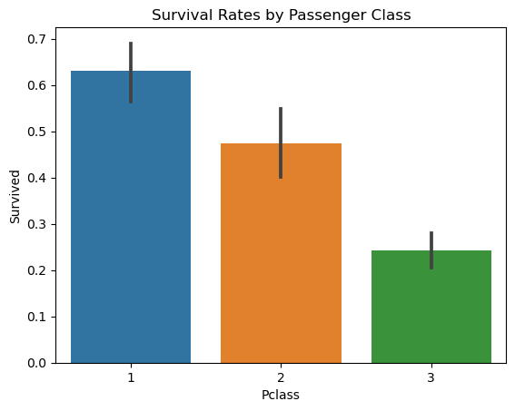

```python
sns.barplot(x='Pclass', y='Survived', data=df)
plt.title('Survival Rates by Passenger Class')
plt.show()
```

#### c. Did gender play a role in survival rates?

```python
gender_survival_rates = df.groupby('Sex')['Survived'].mean()
print("Survival Rates by Gender:")
print(gender_survival_rates)
```

```
Survival Rates by Gender:
Sex
female    0.742038
male      0.188908
Name: Survived, dtype: float64
```

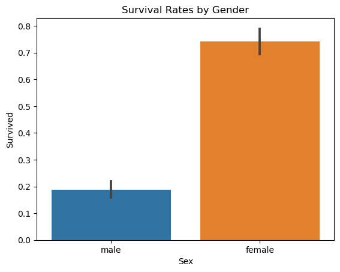

```python
sns.barplot(x='Sex', y='Survived', data=df)
plt.title('Survival Rates by Gender')
plt.show()
```

#### d. Were passengers with siblings or spouses more likely to survive?

```python
sibsp_survival_rates = df.groupby('SibSp')['Survived'].mean()
print("Survival Rates by SibSp (Siblings/Spouses Aboard):")
print(sibsp_survival_rates)
```

```
Survival Rates by SibSp (Siblings/Spouses Aboard):
SibSp
0    0.345395
1    0.535885
2    0.464286
3    0.250000
4    0.166667
5    0.000000
8    0.000000
Name: Survived, dtype: float64
```

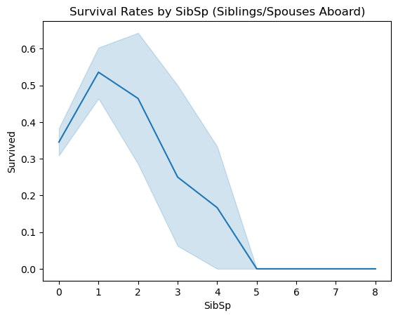

```python
sns.lineplot(x='SibSp', y='Survived', data=df)
plt.title('Survival Rates by SibSp (Siblings/Spouses Aboard)')
plt.show()
```

#### e. Did having parents or children aboard the Titanic influence survival rates?

```python
parch_survival_rates = df.groupby('Parch')['Survived'].mean()
print("Survival Rates by Parch (Parents/Children Aboard):")
print(parch_survival_rates)
```

```
Survival Rates by Parch (Parents/Children Aboard):
Parch
0    0.343658
1    0.550847
2    0.500000
3    0.600000
4    0.000000
5    0.200000
6    0.000000
Name: Survived, dtype: float64
```

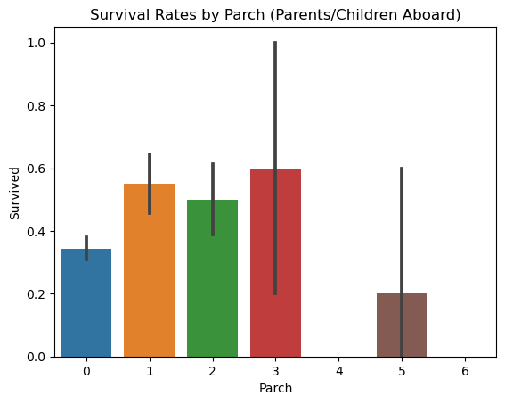

```python
sns.barplot(x='Parch', y='Survived', data=df)
plt.title('Survival Rates by Parch (Parents/Children Aboard)')
plt.show()
```

### Age and Survival

#### a. What was the age distribution of passengers on the Titanic?

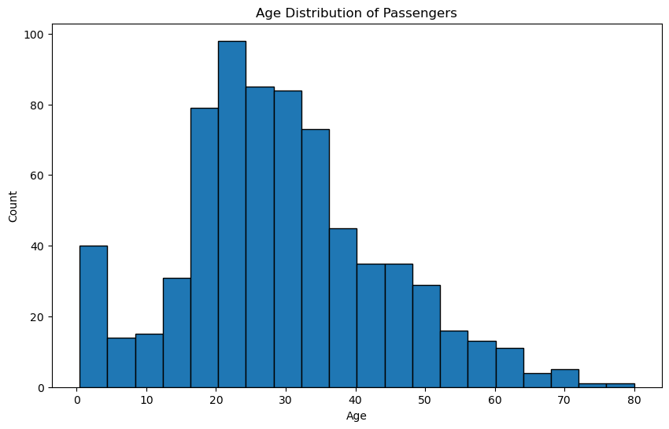

```python
plt.figure(figsize=(10, 6))
df['Age'].plot.hist(bins=20, edgecolor='k')
plt.xlabel('Age')
plt.ylabel('Count')
plt.title('Age Distribution of Passengers')
plt.show()
```

#### b. Did age impact a passenger's likelihood of survival?

```python
age_survival_rates = df.groupby('Age')['Survived'].mean()
print("Survival Rates by Age:")
print(age_survival_rates)
```

```
Survival Rates by Age:
Age
0.42     1.0
0.67     1.0
0.75     1.0
0.83     1.0
0.92     1.0
        ...
70.00    0.0
70.50    0.0
71.00    0.0
74.00    0.0
80.00    1.0
Name: Survived, Length: 88, dtype: float64
```

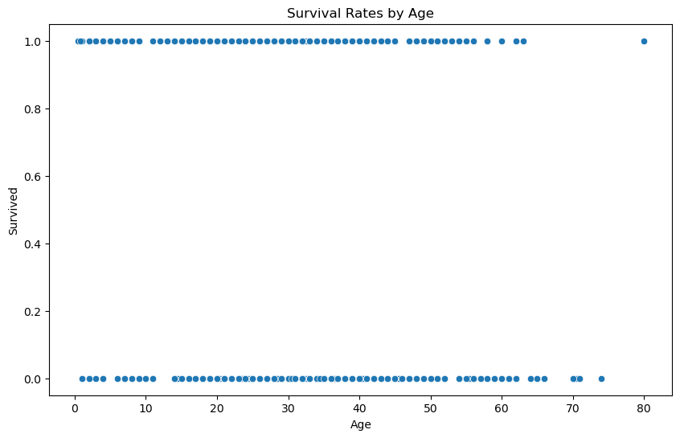

```python
plt.figure(figsize=(10, 6))
sns.scatterplot(x='Age', y='Survived', data=df)
plt.title('Survival Rates by Age')
plt.show()
```

#### c. Were children given priority in the lifeboats?

```python
child_survival_rate = df[df['Age'] < 18]['Survived'].mean()
print("Survival Rate for Children (Age < 18): {:.2%}".format(child_survival_rate))
```

```
Survival Rate for Children (Age < 18): 53.98%
```

#### Ticket Fare and Survival

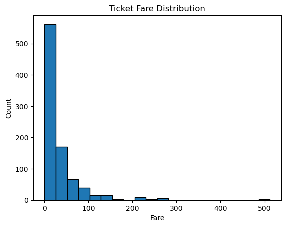

```python
# a. What was the distribution of ticket fares?
df['Fare'].plot.hist(bins=20, edgecolor='k')
plt.xlabel('Fare')
plt.ylabel('Count')
plt.title('Ticket Fare Distribution')
plt.show()
```

#### b. Did passengers who paid more for their tickets have a higher chance of survival?

```python
fare_survival_rates = df.groupby('Fare')['Survived'].mean()
print("Survival Rates by Fare:")
print(fare_survival_rates)
```

```
Survival Rates by Fare:
Fare
0.0000      0.066667
4.0125      0.000000
5.0000      0.000000
6.2375      0.000000
6.4375      0.000000
              ...
227.5250    0.750000
247.5208    0.500000
262.3750    1.000000
263.0000    0.500000
512.3292    1.000000
Name: Survived, Length: 248, dtype: float64
```

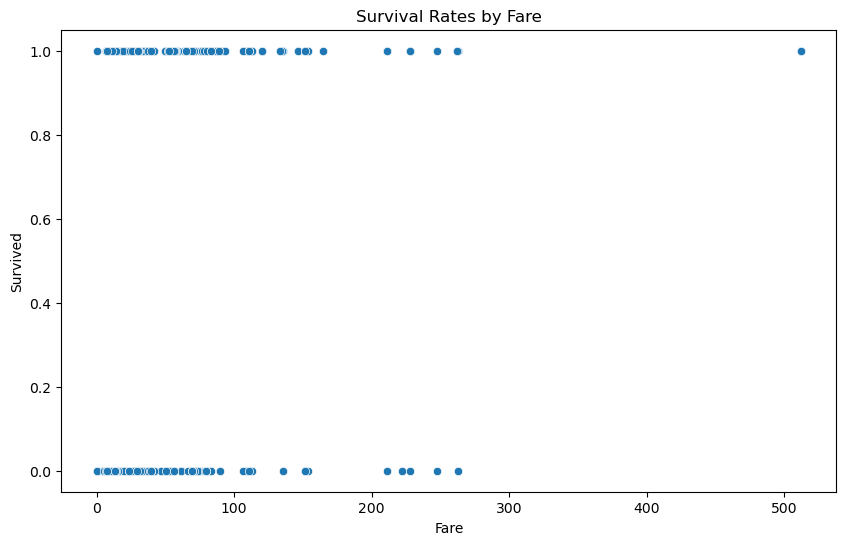

```python
plt.figure(figsize=(10, 6))
sns.scatterplot(x='Fare', y='Survived', data=df)
plt.title('Survival Rates by Fare')
plt.show()
```

#### c. Did the ticket fare correlate with the passenger class?

```python
fare_class_correlation = df[['Fare', 'Pclass']].corr().iloc[0, 1]
print("Correlation between Fare and Pclass: {:.2f}".format(fare_class_correlation))
```

```
Correlation between Fare and Pclass: -0.55
```

### Port of Embarkation

#### a. How many passengers embarked from each of the three ports (Southampton, Cherbourg, and Queenstown)?

```python
port_counts = df['Embarked'].value_counts()
print("Passengers Embarked from Each Port:")
print(port_counts)
```

```
Passengers Embarked from Each Port:
Embarked
S    644
C    168
Q     77
Name: count, dtype: int64
```

#### b. Did the port of embarkation influence a passenger's survival chances?

```python
port_survival_rates = df.groupby('Embarked')['Survived'].mean()
print("Survival Rates by Port of Embarkation:")
print(port_survival_rates)
```

```
Survival Rates by Port of Embarkation:
Embarked
C    0.553571
Q    0.389610
S    0.336957
Name: Survived, dtype: float64
```

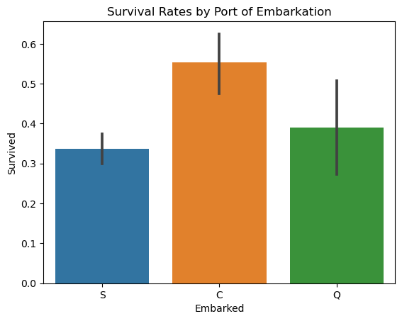

```python
sns.barplot(x='Embarked', y='Survived', data=df)
plt.title('Survival Rates by Port of Embarkation')
plt.show()
```

### Family Size

#### a. What was the average family size on the Titanic?

```python
df['FamilySize'] = df['SibSp'] + df['Parch']
average_family_size = df['FamilySize'].mean()
print("Average Family Size: {:.2f}".format(average_family_size))
```

```
Average Family Size: 0.90
```

#### b. Did passengers traveling alone have a different survival rate compared to those with family members aboard?

```python
alone_survival_rate = df[df['FamilySize'] == 0]['Survived'].mean()
with_family_survival_rate = df[df['FamilySize'] > 0]['Survived'].mean()
print("Survival Rate for Passengers Traveling Alone: {:.2%}".format(alone_survival_rate))
print("Survival Rate for Passengers with Family Aboard: {:.2%}".format(with_family_survival_rate))
```

```
Survival Rate for Passengers Traveling Alone: 30.35%
Survival Rate for Passengers with Family Aboard: 50.56%
```

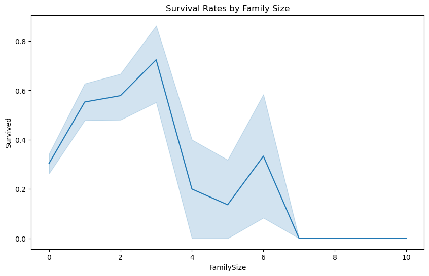

```python
plt.figure(figsize=(10, 6))
sns.lineplot(x='FamilySize', y='Survived', data=df)
plt.title('Survival Rates by Family Size')
plt.show()
```

### Cabin and Deck Information

#### a. How many passengers had cabin information available in the dataset?

```python
cabin_info_available = df['Cabin'].count()
print("Passengers with Cabin Information Available: {}".format(cabin_info_available))
```

```
Passengers with Cabin Information Available: 204
```

#### b. Did the deck level (A, B, C, etc.) where a passenger's cabin was located affect their survival?

```python
df['Deck'] = df['Cabin'].str.extract(r'([A-Z])')
deck_survival_rates = df.groupby('Deck')['Survived'].mean()
print("Survival Rates by Deck:")
print(deck_survival_rates)
```

```
Survival Rates by Deck:
Deck
A    0.466667
B    0.744681
C    0.593220
D    0.757576
E    0.750000
F    0.615385
G    0.500000
T    0.000000
Name: Survived, dtype: float64
```

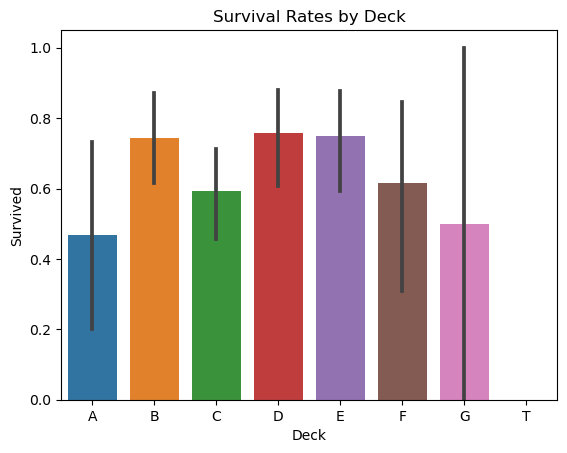

```python
sns.barplot(x='Deck', y='Survived', data=df, order=sorted(df['Deck'].dropna().unique()))
plt.title('Survival Rates by Deck')
plt.show()
```

### Name Analysis

#### a. What are the most common titles (e.g., Mr., Mrs., Miss) among passengers, and did they impact survival?

```python
df['Title'] = df['Name'].str.extract(r' ([A-Za-z]+)\.')
title_counts = df['Title'].value_counts()
print("Most Common Titles:")
print(title_counts)
```

```
Most Common Titles:
Title
Mr          517
Miss        182
Mrs         125
Master       40
Dr            7
Rev           6
Mlle          2
Major         2
Col           2
Countess      1
Capt          1
Ms            1
Sir           1
Lady          1
Mme           1
Don           1
Jonkheer      1
Name: count, dtype: int64
```

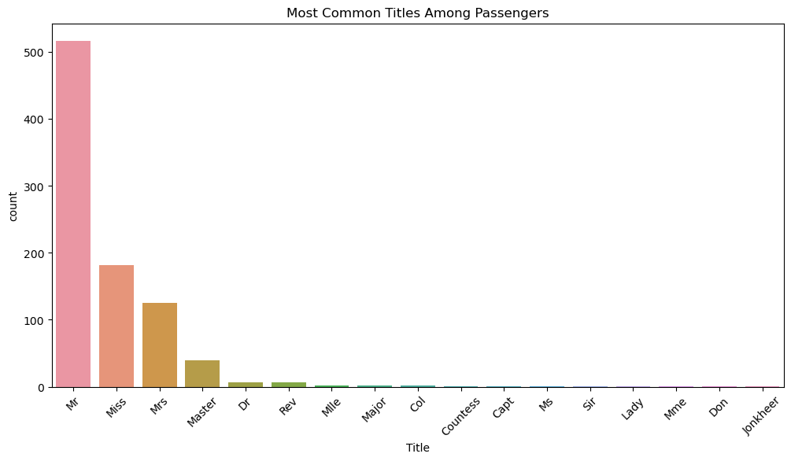

```python
plt.figure(figsize=(12, 6))
sns.countplot(x='Title', data=df, order=title_counts.index)
plt.title('Most Common Titles Among Passengers')
plt.xticks(rotation=45)
plt.show()
```

```python
title_survival_rates = df.groupby('Title')['Survived'].mean()
print("Survival Rates by Title:")
print(title_survival_rates)
```

```
Survival Rates by Title:
Title
Capt        0.000000
Col         0.500000
Countess    1.000000
Don         0.000000
Dr          0.428571
Jonkheer    0.000000
Lady        1.000000
Major       0.500000
Master      0.575000
Miss        0.697802
Mlle        1.000000
Mme         1.000000
Mr          0.156673
Mrs         0.792000
Ms          1.000000
Rev         0.000000
Sir         1.000000
Name: Survived, dtype: float64
```

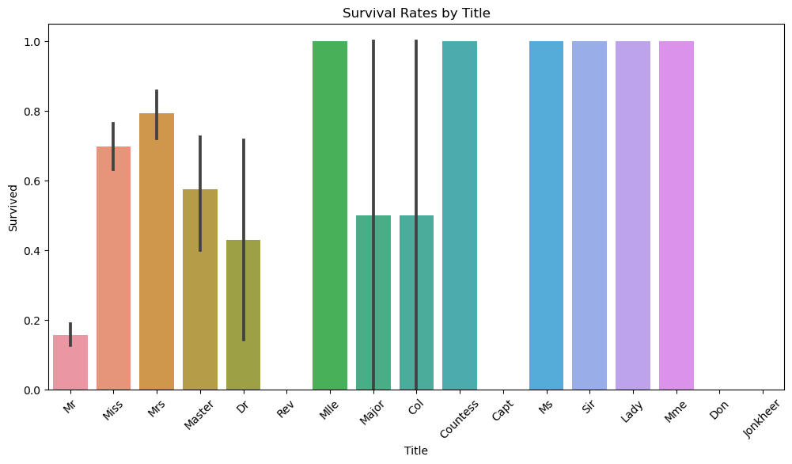

```python
plt.figure(figsize=(12, 6))
sns.barplot(x='Title', y='Survived', data=df, order=title_counts.index)
plt.title('Survival Rates by Title')
plt.xticks(rotation=45)
plt.show()
```

### Missing Data Analysis

#### a. How much missing data is there in the dataset for various attributes, and how should it be handled?

```python
missing_data = df.isnull().sum()
print("Missing Data Summary:")
print(missing_data)
```

```
Missing Data Summary:
PassengerId      0
Survived         0
Pclass           0
Name             0
Sex              0
Age            177
SibSp            0
Parch            0
Ticket           0
Fare             0
Cabin          687
Embarked         2
FamilySize       0
Deck           687
Title            0
dtype: int64
```

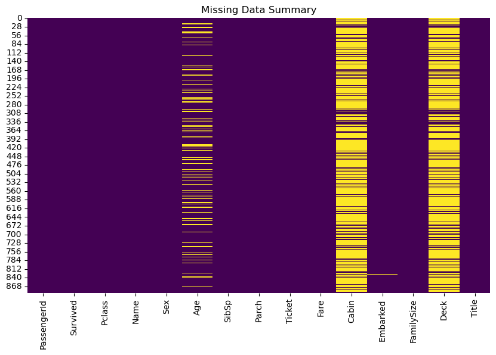

```python
plt.figure(figsize=(10, 6))
sns.heatmap(df.isnull(), cbar=False, cmap='viridis')
plt.title('Missing Data Summary')
plt.show()
```

## Conclusion

##### The number of passengers who embarked from Southampton, Cherbourg, and Queenstown were 644, 168 and 77 respectively.

##### The average family size on the Titanic was 0.90.

##### Passengers traveling alone had a different survival rate compared to those with family members aboard, indicating that family size influenced survival.

##### A limited number of passengers had cabin information available.

##### The color indicates whether the data is missing (yellow) or present (purple).

##### This analysis of the Titanic dataset has provided valuable insights into the factors that influenced the survival of passengers. It highlights the significance of passenger class, gender, age, family size, and other factors in determining survival outcomes during one of the most infamous maritime disasters in history.

##### This project serves as a testament to the importance of data analysis in unraveling historical events and uncovering patterns that can inform our understanding of human behavior in times of crisis.